# Assignment 2

Munan Hou

September 16, 2016

## Exercise 0 Basic Arithmetic

1. Assignment, variables Try some simple commands

```r
a <- 2
b <- 50
c <- 3

a+b
```

```
## [1] 52
```

```r
b/a
```

```
## [1] 25
```

```r
50%%3
```

```
## [1] 2
```

```r
sin(0)
```

```
## [1] 0
```

```r
cos(0)
```

```
## [1] 1
```

```r
sin45 <- sin(pi/4)
4*asin(sin45)
```

```
## [1] 3.141593
```

```r
e3 <- exp(3)
log(e3)
```

```
## [1] 3
```

```r
# create
a_vec <- c(3, 50, 5, 6, 10, 40, 20, 2, 100, 30, 25, 80)
# length
length(a_vec)
```

```
## [1] 12
```

```r
# sum
sum(a_vec)
```

```
## [1] 371
```

```r
# cumulative sum
cumsum(a_vec)
```

```
##  [1]   3  53  58  64  74 114 134 136 236 266 291 371
```

```r
# summary statistics
summary(a_vec)
```

```
##    Min. 1st Qu.  Median    Mean 3rd Qu.    Max.
##    2.00    5.75   22.50   30.92   42.50  100.00
```

```r
# variance
var(a_vec)
```

```
## [1] 1011.72
```

```r
# is it reatlly a vector?
str(a_vec)
```

```
##  num [1:12] 3 50 5 6 10 40 20 2 100 30 ...
```

```r
# was that not clear?
is.vector(a_vec)
```

```
## [1] TRUE
```

```r
# assign the 5th element of a_vec to d
d <- a_vec[5]
a_vec
```

```
##  [1]   3  50   5   6  10  40  20   2 100  30  25  80
```

```r
# what does this mean?
length(d)
```

```
## [1] 1
```

```r
# Really? Well, ...
is.vector(d)
```

```
## [1] TRUE
```

```r
# how about random numbers?
random_vec <- runif(20)
length(random_vec)
```

```
## [1] 20
```

```r
random_vec
```

```
##  [1] 0.7780565 0.5583070 0.2209023 0.7516170 0.5092902 0.8837937 0.6166862
##  [8] 0.4622190 0.5903447 0.9062676 0.2445997 0.7677390 0.4701093 0.2673052
## [15] 0.9623915 0.5448592 0.9990118 0.9514981 0.7631976 0.5125929
```

```r
# what if random_vec was really big?
random_vec_big <- runif(10000)
length(random_vec_big)
```

```
## [1] 10000
```

```r
head(random_vec_big)
```

```
## [1] 0.3105014 0.3925627 0.4500386 0.6618944 0.6793198 0.3064816
```

```r
# need more than 6?
head(random_vec_big, 20)
```

```
##  [1] 0.310501403 0.392562669 0.450038612 0.661894354 0.679319813
##  [6] 0.306481560 0.195389222 0.465180055 0.037710408 0.795168829
## [11] 0.267088954 0.594357029 0.470209172 0.008978952 0.015889239
## [16] 0.746395839 0.515794305 0.789779263 0.621718823 0.792876242
```

```r
# too many decimal places?
options(digits = 2)
tail(random_vec_big)
```

```
## [1] 0.41 0.82 0.86 0.91 0.47 0.33
```

```r
# What if I want my random series to be repeatable?
set.seed(2)
r <- runif(30)
head(r,10)
```

```
##  [1] 0.18 0.70 0.57 0.17 0.94 0.94 0.13 0.83 0.47 0.55
```

```r
r1 <- runif(20)
head(r1,10)
```

```
##  [1] 0.01 0.16 0.81 0.87 0.51 0.63 0.84 0.28 0.67 0.15
```

```r
set.seed(2)
s <- runif(10)
s
```

```
##  [1] 0.18 0.70 0.57 0.17 0.94 0.94 0.13 0.83 0.47 0.55
```

```r
# not enough digits?
options(digits = 4)
head(r)
```

```
## [1] 0.1849 0.7024 0.5733 0.1681 0.9438 0.9435
```

```r
head(s)
```

```
## [1] 0.1849 0.7024 0.5733 0.1681 0.9438 0.9435
```

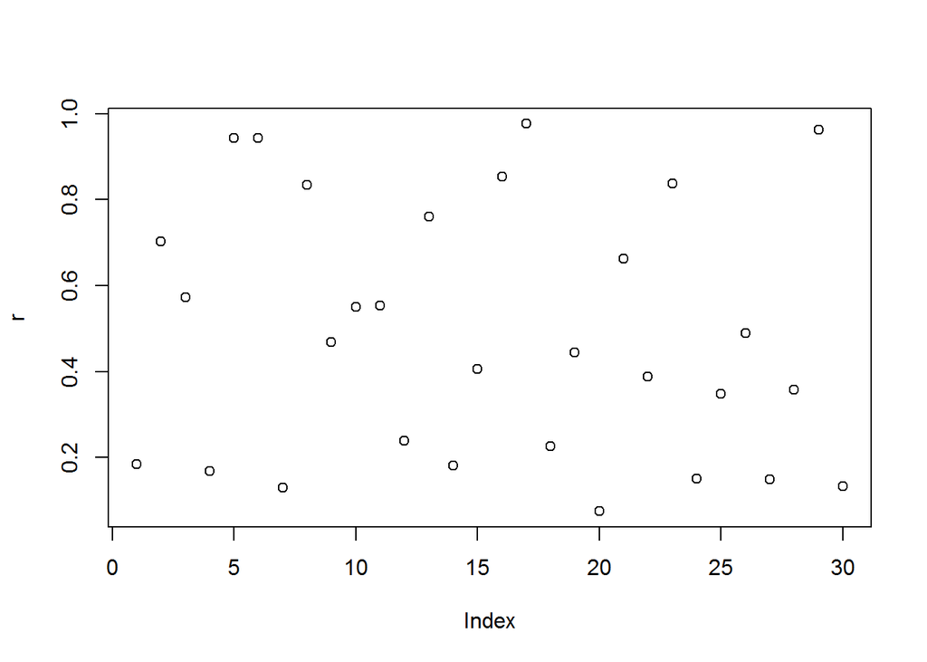

```r
# can I get a picture of that?
plot(r)
```

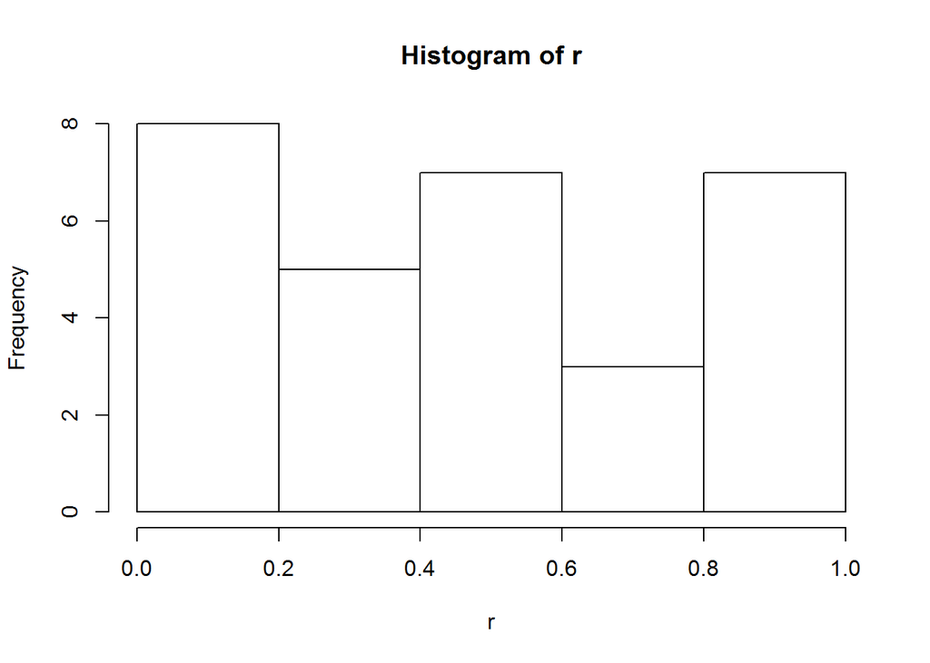

```r
# that's not very helpful. Histogram.
hist(r)
```

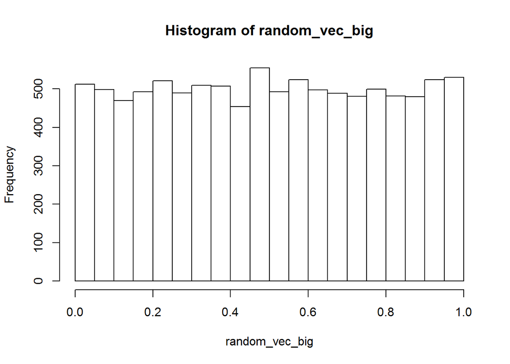

```r
# doesn't look uniform? increase the sample size
hist(random_vec_big)
```

All these blocks of R may not be what you need. Remember a_vec? Sure, avec is (3, 50, 5, 6, 10, 40, 20, 2, 100, 30, 25, 80). Here’s a_vec’s mean 30.9167. Wow – a_vec is a strange set of data, what does it look like?

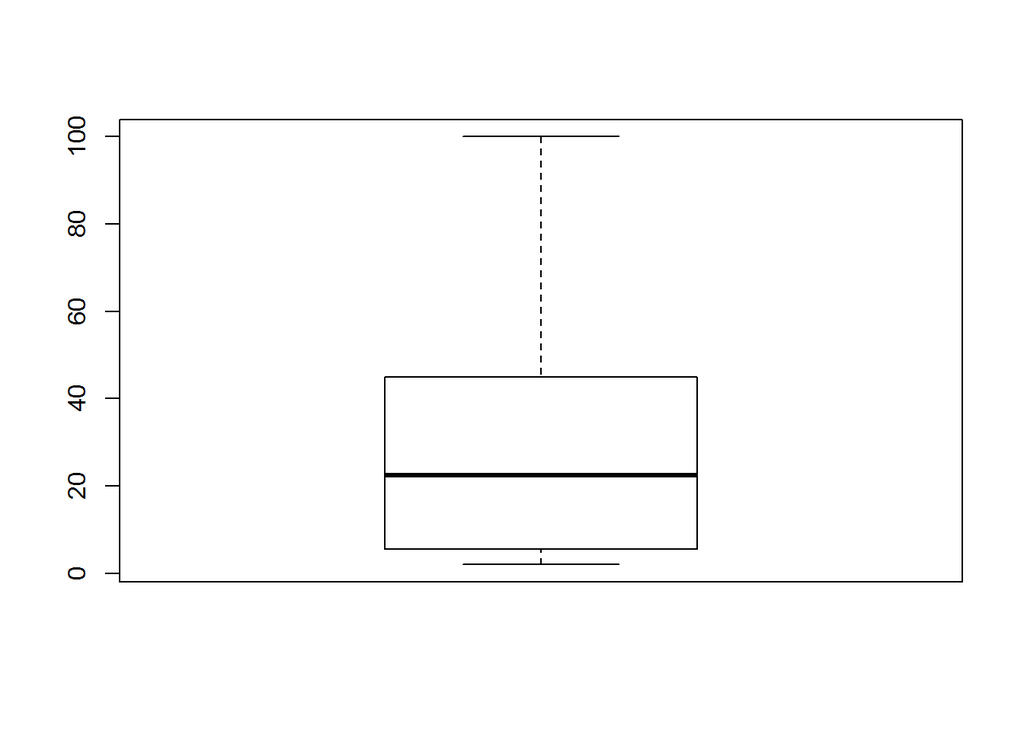

```r
boxplot(a_vec)
```

3. Finally, let’s look at matrice, lists, and data.frames

```r
# make a random matrix
A <- matrix(data = floor(30*runif(16)), nrow = 4)
A
```

```
##      [,1] [,2] [,3] [,4]
## [1,]   16   12   13   25
## [2,]    7   25    2    4
## [3,]   22   29   19   10
## [4,]    5    6   11   14
```

```r
# how big is the matrix?
dim(A)
```

```
## [1] 4 4
```

```r
# Let's make a vector to multiply by A
b <- floor(20*runif(dim(A)[2]))
b
```

```
## [1]  2  7 19  2
```

```r
# solve Ax = b
x <- solve(A,b)
x
```

```
## [1]  0.2828  0.2370  0.5835 -0.5182
```

```r
b1 <- A%*%x
b1
```

```
##      [,1]
## [1,]    2
## [2,]    7
## [3,]   19
## [4,]    2
```

```r
b2 <- as.vector(A%*%x) #coerce b2 into a vector (column convert to roll)
b2
```

```
## [1]  2  7 19  2
```

```r
# inner product dot(e,f) = e'f
e <- floor(20*runif(4))
f <- floor(20*runif(4))
e
```

```
## [1]  0  3 16 17
```

```r
f
```

```
## [1] 10 12 16  5
```

```r
crossprod(e,f)
```

```
##      [,1]
## [1,]  377
```

```r
sum(e*f)
```

```
## [1] 377
```

```r
t(e)%*%f #transfer e crossprod f?
```

```
##      [,1]
## [1,]  377
```

```r
# outer product
outer(e,f,"*")
```

```
##      [,1] [,2] [,3] [,4]
## [1,]    0    0    0    0
## [2,]   30   36   48   15
## [3,]  160  192  256   80
## [4,]  170  204  272   85
```

```r
outer(e,f,">")
```

```
##       [,1]  [,2]  [,3]  [,4]
## [1,] FALSE FALSE FALSE FALSE
## [2,] FALSE FALSE FALSE FALSE
## [3,]  TRUE  TRUE FALSE  TRUE
## [4,]  TRUE  TRUE  TRUE  TRUE
```

```r
#using automatic coersion
outer(e,f,">")*1
```

```
##      [,1] [,2] [,3] [,4]
## [1,]    0    0    0    0
## [2,]    0    0    0    0
## [3,]    1    1    0    1
## [4,]    1    1    1    1
```

## Exercise 1 Vectors

1. Create the vectors:
1. (1,2,3,…,19,20)

```r
e1q1a <- c(1:20)
```

2. (20,19,…,2,1)

```r
e1q1b <- c(20:1)
```

3. (1,2,3,…,19,20,19,18,…,2,1)

```r
e1q1c <- c(c(1:20),c(19:1))
head(e1q1c,39)
```

```
##  [1]  1  2  3  4  5  6  7  8  9 10 11 12 13 14 15 16 17 18 19 20 19 18 17
## [24] 16 15 14 13 12 11 10  9  8  7  6  5  4  3  2  1
```

4. (4,6,3) and assign it to the name tmp.

```r
tmp <- c(4,6,3)
```

For parts (e), (f) and (g) look at the help for the function rep.

5. (4,6,3, 4,6,3,…,4,6,3) where there are 10 occurrences of 4.

```r
e1q1e <- c(rep(tmp, time=10))
e1q1e
```

```
##  [1] 4 6 3 4 6 3 4 6 3 4 6 3 4 6 3 4 6 3 4 6 3 4 6 3 4 6 3 4 6 3
```

6. (4,6,3, 4,6,3,…,4,6,3,4) where there are 11 occurrences of 4, 10 occurrences of 6 and 10 occurrences of 3.

```r
e1q1f <- c(rep(tmp, length=31))
e1q1f
```

```
##  [1] 4 6 3 4 6 3 4 6 3 4 6 3 4 6 3 4 6 3 4 6 3 4 6 3 4 6 3 4 6 3 4
```

7. (4,4,…,4, 6,6,…,6, 3,3,…,3) where there are 10 occurrences of 4, 20 occurrences of 6 and 30 occurrences of 3.

```r
e1q1g <- c(rep(tmp, c(10,20,30)))
e1q1g
```

```
##  [1] 4 4 4 4 4 4 4 4 4 4 6 6 6 6 6 6 6 6 6 6 6 6 6 6 6 6 6 6 6 6 3 3 3 3 3
## [36] 3 3 3 3 3 3 3 3 3 3 3 3 3 3 3 3 3 3 3 3 3 3 3 3 3
```

2. Create a vector of the values of e^x*cos(x) at x = 3,3.1,3.2,…,6. Make a plot of the multiplicants and the product.

```r
par(new=TRUE)
```

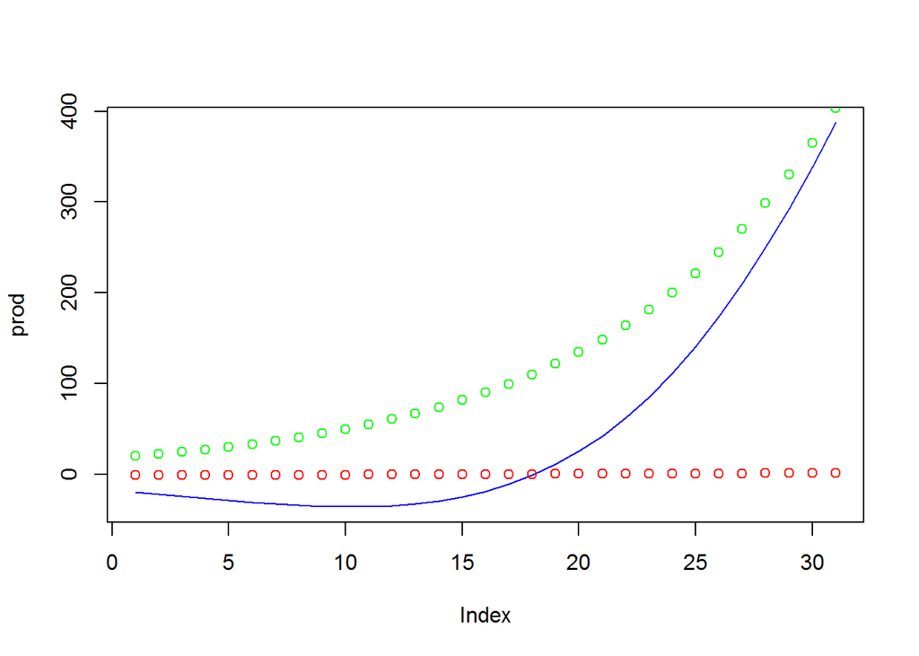

```r
x <- seq(3,6,by=0.1)
prod <- exp(x)*cos(x)
plot(prod, col="blue", type="l") #(type set to "line")
points(cos(x),col="red")
points(exp(x),col="green")
```

```r
x <- seq(3, 36, by=3)
y <- seq(1, 34, by=3)
a <- (0.1^x)*(0.2^y)
a
```

```
##  [1] 2.000e-04 1.600e-09 1.280e-14 1.024e-19 8.192e-25 6.554e-30 5.243e-35
##  [8] 4.194e-40 3.355e-45 2.684e-50 2.147e-55 1.718e-60
```

2. (2, (2^2)/2, (2^3)/3, … , (2^25)/25)

```r
x <- seq(1:25)
b <- (2^x)/x
b
```

```
##  [1] 2.000e+00 2.000e+00 2.667e+00 4.000e+00 6.400e+00 1.067e+01 1.829e+01
##  [8] 3.200e+01 5.689e+01 1.024e+02 1.862e+02 3.413e+02 6.302e+02 1.170e+03
## [15] 2.185e+03 4.096e+03 7.710e+03 1.456e+04 2.759e+04 5.243e+04 9.986e+04
## [22] 1.907e+05 3.647e+05 6.991e+05 1.342e+06
```

4. Calculate the following
1. summary of (i^3+4*i^2), where i ranges from 10 to 100.

```r
i <- c(10:100)
a <- sum(i^3+4*i^2)
a
```

```
## [1] 26852735
```

```r
i <- (1:25)
b <- sum((2^i)/i + (3^i)/(i^2))
b
```

```
## [1] 2.129e+09
```

5. Use the function “paste”" to create the following character vectors of length 30:
1. (“label 1”, “label 2”, ….., “label 30”). Note that there is a single space between label and the number following.

```r
paste("label", 1:30)
```

```
##  [1] "label 1"  "label 2"  "label 3"  "label 4"  "label 5"  "label 6"
##  [7] "label 7"  "label 8"  "label 9"  "label 10" "label 11" "label 12"
## [13] "label 13" "label 14" "label 15" "label 16" "label 17" "label 18"
## [19] "label 19" "label 20" "label 21" "label 22" "label 23" "label 24"
## [25] "label 25" "label 26" "label 27" "label 28" "label 29" "label 30"
```

2. (“fn1”, “fn2”, …, “fn30”). In this case, there is no space between fn and the number following.

```r
paste0("fn", 1:30)
```

```
##  [1] "fn1"  "fn2"  "fn3"  "fn4"  "fn5"  "fn6"  "fn7"  "fn8"  "fn9"  "fn10"
## [11] "fn11" "fn12" "fn13" "fn14" "fn15" "fn16" "fn17" "fn18" "fn19" "fn20"
## [21] "fn21" "fn22" "fn23" "fn24" "fn25" "fn26" "fn27" "fn28" "fn29" "fn30"
```

6. Execute the following lines which create two vectors of random integers which are chosen with replacement from the integers 0, 1, …, 999. Both vectors have length 250.

```r
set.seed(50)
xVec <- sample(0:999, 250, replace=T)
yVec <- sample(0:999, 250, replace=T)
```

Supposex = (x1,x2,…,xn) denotes the vector xVec andy = (y1,y2,…,yn) denotes the vector yVec.

1. Create the vector (y2 −x1,…,yn −xn−1). Plot the vector.

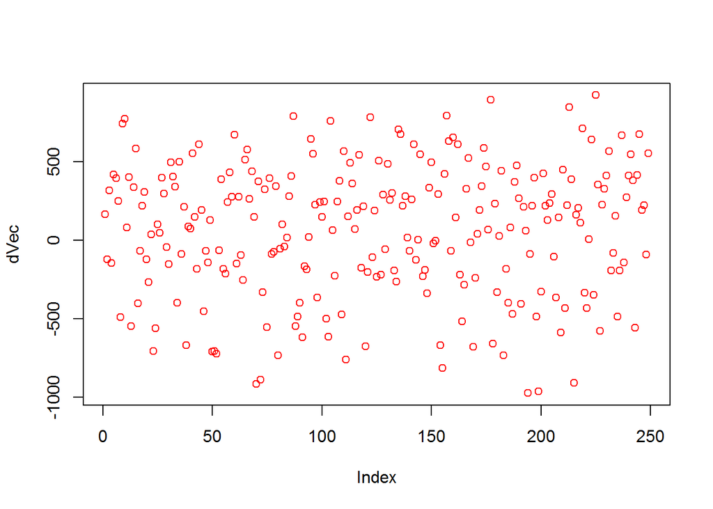

```r
yVeca <- yVec[-1]#delete the first element
xVeca <- xVec[-length(xVec)]#dropping the last one, can also use"-250" instead of "-length"
dVec <- yVeca - xVeca
plot(dVec, col="red")
```

2. Create the vector (sin(y1)/cos(x2), sin(y2)/cos(x3), sin(yn-1)/cos(xn))

```r
yVecb <- yVec[-length(yVec)]
xVecb <- xVec[-1]
eVec <- sin(yVecb)/cos(xVecb)
eVec
```

```
##   [1]   0.88603  -1.44185   0.82807  -1.61592  -0.86017  20.26356  -0.79930
##   [8]   1.72414  -0.08094  -0.74896  -2.59867  -0.37361  31.11472   0.12356
##  [15]  -0.35925  -0.90744   0.34374   5.78206  -2.57419  -0.78661  -0.59855
##  [22]   0.98936   0.33043  -1.75125  -0.59436   1.05375   0.65497  -0.11597
##  [29]  -0.97177   0.57180   0.75799  -0.49259  -0.99433   0.05377  -3.77616
##  [36]  20.54903   0.77785   1.28147  -0.51651   6.66903  -0.92970 -10.93066
##  [43]  -3.13103  30.87943  -1.14282   0.36758   1.18480   0.94594   0.93340
##  [50]   0.93633 -11.05384   2.76893   0.97488  -0.08932  -1.33617  -3.30066
##  [57]   0.62663  -1.96486   0.08654   0.56695  44.07631  -1.11765   0.11230
##  [64]  -0.46073  -0.13861   0.84026   2.64709  -1.63175  -9.63023  -2.15553
##  [71]  -0.42771   3.24955  -4.23453   0.93067  -0.88388   0.69339   1.72841
##  [78]  -8.22083   1.69276   1.02075  -3.21968  -0.90739   1.11332   0.59579
##  [85]   0.19571  -0.17975   4.38930   0.64431  -1.54509  -0.26537  -0.81679
##  [92]   1.34164  -1.03400  -1.33640  -0.44444   0.96778  -0.09545  -0.63686
##  [99]  -2.30844  -0.11384   1.08800   1.06852  -0.30428  -1.77045  -1.45269
```

[output cut: 21 more lines]

3. Create the vector (x1 +2x2 −x3, x2 +2x3 −x4, … , xn−2 +2xn−1 −xn).

```r
xVecc1 <- xVec[-c((length(xVec)-1):length(xVec))]
xVecc2 <- xVec[-c(1, length(xVec))]
xVecc3 <- xVec[-c(1, 2)]
fVec <- xVecc1 + 2*xVecc2 - xVecc3
fVec
```

```
##   [1] 1382   70 1221 1749  -98  796 1949  623 -134  618  288 1472  517  -45
##  [15]  794 1982 1489  344 -206 1207  292  771 2085  810 1032 1547  767  537
##  [29]  702  676  737  664 1451  435 1355  168 1150  989  926  348 1757 1299
##  [43]  409 -497  501 2150 1157 1081 1323 2030 1887 1744  879  590  493 1330
##  [57] 1254 1281  465  767 1691  464 1238  805 -519 1425  710 -611 1517  963
##  [71] 1836 2243 -158 1860  606  506 1917 1304 2021 2025  238  226  733 1538
##  [85]  581 -659  824 1109 1136 1339 1239 1584 2300  562  567 -375 1372  761
##  [99] 1142  714 1801 2220  624 -806 1738  268  398 1941  668 2037  829  345
## [113]  337  -45  635 -285 1225  691 1792 2216  123  538 1130 1124 1172  944
## [127]  271  -62  229  785  -70 1346 1622  381  104 1036 1015  199  589 1399
## [141]  601  506  560 -145  171 1204 1427 1278 1128  615  269   37 1521 2172
## [155] 1602  464   74 1575  599   88 -267 1185 1655 1564 1420  880  229 1651
## [169]  959 1306 2008 1243  267 1110  556 -791 1300  844 1578 2427  708 1554
## [183] 1439 1150 1269 2274 1419 1067  187 2071  781 -148 1767 1851 1019 -196
## [197]  554 2223 1710  -90  788 1209  876 1322  275 1191  323 1570 1234  768
## [211] 1715  903 -768 1546 1452  -47 1125 -330  871 2463  894  133  975  201
## [225] -137 1553  299  865  746  184  267  839  -63  863 2411  133 1739 1145
## [239] 1015   47  209 1468  846   10 1146   31 1405 1058
```

4. Calculate summary of (e^(-x(i-1)))/(xi+10) as i goes from 1 to n-1.

```r
e <- 2.718281828459
xVecd1 <- xVec[-1]
xVecd2 <- xVec[-length(xVec)]
gVec <- (e^(-xVecd1))/(xVecd2+10)
gVec
```

```
##   [1] 2.276e-193  3.096e-90  0.000e+00 2.073e-226  1.488e-22 4.963e-306
##   [7] 3.937e-284  8.765e-22  6.524e-49 3.606e-172 3.739e-120 4.036e-281
##  [13]  5.577e-37 5.766e-123 9.100e-297  0.000e+00 9.771e-162  1.947e-35
##  [19]  1.301e-75 1.676e-270  2.424e-87 2.205e-311  0.000e+00 7.457e-138
##  [25] 1.602e-285 3.913e-254 4.146e-115 7.279e-144 4.528e-163 8.812e-159
##  [31] 1.746e-180 3.910e-193 9.030e-272 6.147e-100 2.147e-275  4.428e-56
##  [37] 2.769e-307 1.433e-165 3.235e-202 4.796e-161  0.000e+00 2.182e-124
##  [43]  1.417e-43  1.262e-26 1.517e-306  0.000e+00 1.285e-202 4.762e-313
##  [49]  0.000e+00  0.000e+00  0.000e+00 3.949e-281 2.156e-133 1.078e-158
##  [55] 7.228e-188 6.934e-314 1.365e-231 2.224e-225 5.765e-119 3.443e-254
##  [61] 5.858e-288  4.180e-89 4.186e-257  1.590e-59  2.258e-19 7.755e-317
##  [67]  4.389e-30  1.215e-61  0.000e+00 6.810e-224  0.000e+00 8.495e-291
##  [73]  1.085e-35  0.000e+00  5.427e-68 2.950e-288  0.000e+00 7.162e-287
##  [79]  0.000e+00 1.560e-239  7.486e-11 2.202e-149 5.930e-207 1.157e-239
##  [85]  1.011e-11  1.269e-02 4.349e-297 8.811e-237 1.387e-283 1.220e-303
```

[output cut: 27 more lines]

7. This question uses the vectors “xVec”" and “yVec”" created in the previous question and the functions “sort”“,”order“,”mean“,”sqrt“,”sum" and “abs”.

```r
set.seed(50)
xVec <- sample(0:999, 250, replace=T)
yVec <- sample(0:999, 250, replace=T)
```

1. Pick out the values in yVec which are > 600. Make a chart that shows the data points with values > 600 as a subset.

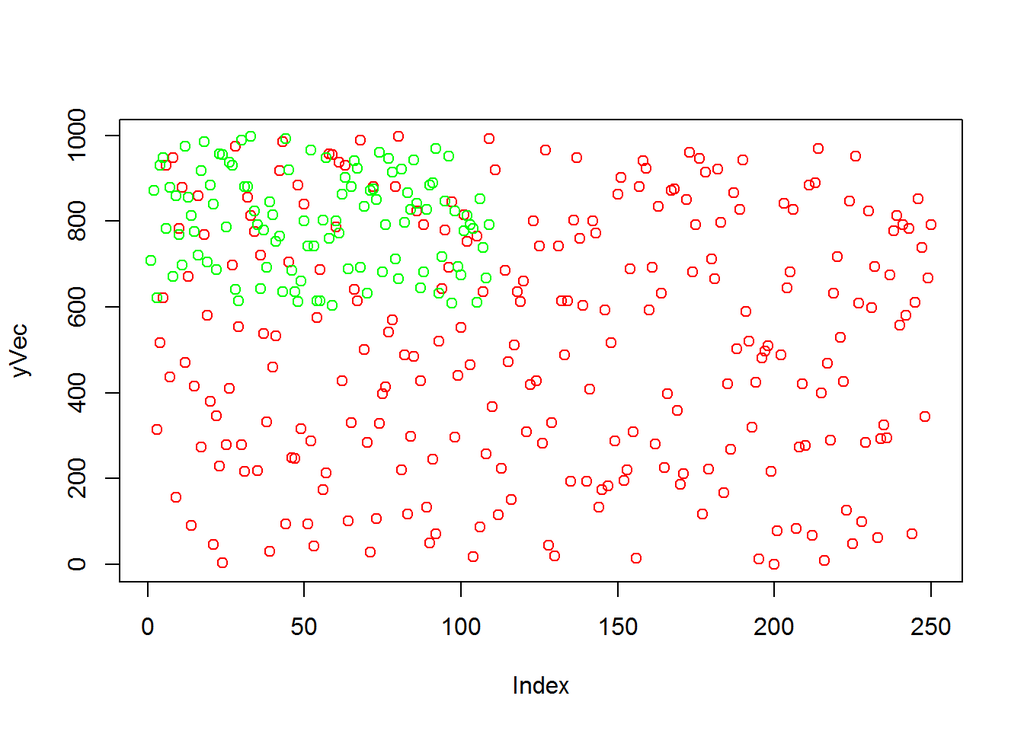

```r
plot(yVec, col="red")
bVec <- yVec[yVec>600]
points(bVec, col="green")
```

```r
bVec
```

```
##   [1] 709 871 621 930 948 783 878 671 860 768 698 974 855 813 776 721 917
##  [18] 985 705 884 840 687 957 955 786 938 930 641 615 988 881 881 997 823
##  [35] 791 643 779 693 845 815 752 766 635 993 919 686 635 613 660 800 743
##  [52] 965 743 615 615 803 948 760 604 800 772 863 902 689 881 941 924 693
##  [69] 835 632 872 876 850 961 681 791 947 915 712 665 921 798 866 828 942
##  [86] 841 645 681 827 884 890 970 632 717 846 952 609 824 695 675 777 813
## [103] 792 783 611 853 738 668 791
```

2. What are the index positions in yVec of the values which are > 600?

```r
i <- (1:250)
c <- (601:999)
n <- c(is.element(yVec[i], c)*1)
n
```

```
##   [1] 1 1 0 0 1 1 0 1 0 1 1 0 1 0 0 1 0 1 0 0 0 0 0 0 0 0 1 1 0 0 0 1 1 1 0
##  [36] 1 0 0 0 0 0 1 1 0 1 0 0 1 0 1 0 0 0 0 1 0 0 1 1 1 1 0 1 0 0 1 1 1 0 0
##  [71] 0 1 0 0 0 0 0 0 1 1 0 0 0 0 0 1 0 1 0 0 0 0 0 1 1 1 1 0 0 0 1 1 0 0 1
## [106] 0 1 0 1 0 1 0 0 1 0 0 0 1 1 1 0 0 1 0 1 0 1 0 0 0 1 1 0 1 0 1 1 1 1 0
## [141] 0 1 1 0 0 0 0 0 0 1 1 0 0 1 0 0 1 1 1 0 1 0 1 1 0 0 1 1 0 0 0 1 1 1 1
## [176] 1 0 1 0 1 1 1 1 0 0 0 1 0 1 1 0 0 0 0 0 0 0 0 0 0 0 0 1 1 1 1 0 0 0 0
## [211] 1 0 1 1 0 0 0 0 1 1 0 0 0 1 0 1 1 0 0 1 0 1 0 0 0 0 1 1 1 0 1 0 1 0 1
## [246] 1 1 0 1 1
```

3. What are the values in xVec which correspond to the values in yVec which are > 600? (By correspond, we mean at the same index positions.)

```r
m <- xVec*n
m
```

```
##   [1] 708 437   0   0 513  44   0 646   0 107 390   0 640   0   0 676   0
##  [18] 364   0   0   0   0   0   0   0   0 577 257   0   0   0 408 437 618
##  [35]   0 627   0   0   0   0   0 836 278   0  55   0   0 458   0 803   0
##  [52]   0   0   0 358   0   0 525 511 266 578   0 197   0   0  38 724  61
##  [69]   0   0   0 995   0   0   0   0   0   0 652 956   0   0   0   0   0
##  [86]  19   0 680   0   0   0   0   0 760  48 294  69   0   0   0 505 964
## [103]   0   0  24   0  10   0 840   0 878   0   0 113   0   0   0 789 444
## [120] 986   0   0 537   0 515   0 263   0   0   0 359 189   0 457   0 274
## [137] 543 324 176   0   0 160 260   0   0   0   0   0   0 407 216   0   0
## [154] 977   0   0 148 293 660   0 137   0 852 743   0   0 353 371   0   0
## [171]   0 768 339 203 478  49   0 880   0 996 894 357 900   0   0   0 972
## [188]   0 467 324   0   0   0   0   0   0   0   0   0   0   0   0 517 446
## [205] 533 190   0   0   0   0 501   0 124  14   0   0   0   0   5 863   0
## [222]   0   0 399   0 256 678   0   0 188   0 258   0   0   0   0 110 957
## [239] 285   0  34   0 631   0 179 545 123   0 238 178
```

```r
i <- (1:250)
xbar <- mean(xVec[i])
xbar
```

```
## [1] 451.9
```

```r
v <- c(sqrt(abs(xVec[i] - xbar)))
v
```

```
##   [1] 16.0045  3.8543 15.8700 17.7523  7.8195 20.1954 15.7208 13.9336
##   [9] 20.2449 18.5703  7.8649 13.5224 13.7166 19.3612 13.2233 14.9714
##  [17] 19.5741  9.3732 19.4385 16.8480 12.8119 16.0890 16.0669 19.7521
##  [25] 11.9522 14.0764 11.1868 13.9591 11.3073  9.1573  9.6879  6.6224
##  [33]  3.8543 12.8897 15.1610 13.2342 18.1894 15.7843  8.8801  2.4787
##  [41]  9.4263 19.5996 13.1854 18.9435 19.9212 15.7526 22.4086  2.4787
##  [49] 16.1600 18.7388 23.3269 17.6959 13.6801 12.3635  9.6879  5.1823
##  [57] 16.2217  8.5524  7.6905 13.6329 11.2314 14.2529 15.9642 11.5388
##  [65] 17.9682 20.3435 16.4968 19.7701 17.7723 22.1843  7.4259 23.3055
##  [73] 14.4618 19.4385 22.6968 17.4315 14.3228 22.4532 14.1472 22.4532
##  [81]  9.5469 20.8532 10.6234  4.1405  9.5992 20.8052 21.2334 15.1044
##  [89]  9.2274 13.8976 15.4643 15.3670 19.3944 17.5540 20.0962 12.5641
##  [97] 19.5667 18.8453 11.8683 14.7018  7.2900 22.6306 13.4218 21.0679
## [105] 20.6847 20.2520 21.0204 12.7336 19.7014  9.9426 20.6433 19.4899
## [113] 16.0890 18.4080 19.2316 11.3954 18.9962 18.3615  2.8029 23.1116
```

[output cut: 17 more lines]

5. How many values in yVec are within 200 of the maximum value of the terms in yVec?

```r
i <- (1:250)
q <- max(yVec[i]) - 200
q
```

```
## [1] 797
```

```r
c <- (q:max(yVec[i]))
n <- c(is.element(yVec[i], c)*1)
sum(n[i])
```

```
## [1] 57
```

6. How many numbers in xVec are divisible by 2? (Note that the modulo operator is denoted %%.)

```r
i <- (1:250)
z <- c(is.element(xVec[i]%%2,0)*1)
sum(z[i])
```

```
## [1] 124
```

```r
g <- sort(xVec, decreasing=FALSE)
g
```

```
##   [1]   1   5   8  10  14  17  18  19  20  24  29  34  38  38  42  42  44
##  [18]  48  48  49  55  59  61  63  69  72  74  74  76  77  82  84  91  93
##  [35]  99 107 109 110 113 113 120 121 123 124 127 129 136 137 148 148 160
##  [52] 168 171 174 176 178 179 188 189 190 193 193 197 197 200 203 206 216
##  [69] 222 224 224 238 256 256 257 258 260 263 266 269 274 275 277 278 280
##  [86] 285 293 294 299 308 309 311 322 324 324 324 339 339 353 353 357 358
## [103] 358 359 363 364 365 368 371 373 376 382 390 395 399 403 405 407 408
## [120] 415 425 435 437 437 444 446 452 457 457 458 458 460 461 467 469 477
## [137] 478 480 497 501 505 507 511 513 515 517 523 525 530 533 537 537 541
## [154] 543 543 544 545 545 554 572 577 578 585 603 614 616 618 621 624 625
## [171] 627 631 632 638 639 640 645 646 650 652 655 657 660 661 667 668 669
## [188] 676 678 680 683 688 691 699 700 701 702 707 708 710 713 715 724 743
## [205] 760 760 765 767 768 781 787 789 803 807 807 811 828 828 835 836 840
## [222] 842 852 860 862 863 865 866 870 878 880 894 900 920 928 944 954 956
## [239] 956 957 963 964 967 972 977 986 987 995 996 996
```

```r
i <- seq(1, 250, by=3)
h <- c(yVec[i])
h
```

```
##  [1] 709 517 437 783 671 860 581 347 279 974 216 776 538 460 985 248 317
## [18] 288 687 957 938 101 615 285 106 414 881 488 484 791 246 643 845 553
## [35] 465  87 993 116 473 635 310 428 965  19 489 803 604 800 175 516 902
## [52] 689 881 593 835 398 358 850 791 915 665 167 866 942 320 482 216 488
## [69] 681 273 884 970 469 717 127 952 284 695 325 777 792  72 738 791
```

8. By using the function “cumprod” or otherwise, calculate 1+2/3+2/3*4/5+2/3*4/5*6/7+ … +2/3*4/5* … *38/39

```r
i <- c(1:19)
a <- cumprod(2*i)
b <- cumprod(2*i+1)
j <- 1+sum(a[i]/b[i])
j
```

```
## [1] 6.976
```

## Exercise 2 Matrices

1.(a)

```r
A <- matrix(data = c(1,1,3,5,2,6,-2,-1,-3), nrow = 3, byrow = TRUE)
A
```

```
##      [,1] [,2] [,3]
## [1,]    1    1    3
## [2,]    5    2    6
## [3,]   -2   -1   -3
```

```r
A%*%A%*%A
```

```
##      [,1] [,2] [,3]
## [1,]    0    0    0
## [2,]    0    0    0
## [3,]    0    0    0
```

```r
Ab <- A
Ab[7:9] <- Ab[4:6]+A[7:9]
Ab
```

```
##      [,1] [,2] [,3]
## [1,]    1    1    4
## [2,]    5    2    8
## [3,]   -2   -1   -4
```

```r
b <- c(10, -10, 10)
B <- matrix(data = c(rep(b, time=15)), nrow = 15, byrow = TRUE)
B
```

```
##       [,1] [,2] [,3]
##  [1,]   10  -10   10
##  [2,]   10  -10   10
##  [3,]   10  -10   10
##  [4,]   10  -10   10
##  [5,]   10  -10   10
##  [6,]   10  -10   10
##  [7,]   10  -10   10
##  [8,]   10  -10   10
##  [9,]   10  -10   10
## [10,]   10  -10   10
## [11,]   10  -10   10
## [12,]   10  -10   10
## [13,]   10  -10   10
## [14,]   10  -10   10
## [15,]   10  -10   10
```

```r
BT <- t(B) #Transfer B
BT
```

```
##      [,1] [,2] [,3] [,4] [,5] [,6] [,7] [,8] [,9] [,10] [,11] [,12] [,13]
## [1,]   10   10   10   10   10   10   10   10   10    10    10    10    10
## [2,]  -10  -10  -10  -10  -10  -10  -10  -10  -10   -10   -10   -10   -10
## [3,]   10   10   10   10   10   10   10   10   10    10    10    10    10
##      [,14] [,15]
## [1,]    10    10
## [2,]   -10   -10
## [3,]    10    10
```

```r
BT %*% B
```

```
##       [,1]  [,2]  [,3]
## [1,]  1500 -1500  1500
## [2,] -1500  1500 -1500
## [3,]  1500 -1500  1500
```

```r
matE <- matrix(data = seq(0, 0, length=36), nrow = 6, byrow = TRUE)
matE
```

```
##      [,1] [,2] [,3] [,4] [,5] [,6]
## [1,]    0    0    0    0    0    0
## [2,]    0    0    0    0    0    0
## [3,]    0    0    0    0    0    0
## [4,]    0    0    0    0    0    0
## [5,]    0    0    0    0    0    0
## [6,]    0    0    0    0    0    0
```

```r
row(matE)
```

```
##      [,1] [,2] [,3] [,4] [,5] [,6]
## [1,]    1    1    1    1    1    1
## [2,]    2    2    2    2    2    2
## [3,]    3    3    3    3    3    3
## [4,]    4    4    4    4    4    4
## [5,]    5    5    5    5    5    5
## [6,]    6    6    6    6    6    6
```

```r
c <- c(0, 1, 0, 0, 0, 0, 1)
C <- matrix(data=rep(c, len=36), nrow = 6, byrow = TRUE)
C
```

```
##      [,1] [,2] [,3] [,4] [,5] [,6]
## [1,]    0    1    0    0    0    0
## [2,]    1    0    1    0    0    0
## [3,]    0    1    0    1    0    0
## [4,]    0    0    1    0    1    0
## [5,]    0    0    0    1    0    1
## [6,]    0    0    0    0    1    0
```

```r
#or
#A <- matrix(0, nrow=6, ncol=6, byrow=TRUE)
#(abs(col(A)-row(A))==1)*1
```

```r
outer(0:4,0:4,"+") #if no "+" then default is multiplication
```

```
##      [,1] [,2] [,3] [,4] [,5]
## [1,]    0    1    2    3    4
## [2,]    1    2    3    4    5
## [3,]    2    3    4    5    6
## [4,]    3    4    5    6    7
## [5,]    4    5    6    7    8
```

```r
outer(0:4,0:4,"+") %% 5
```

```
##      [,1] [,2] [,3] [,4] [,5]
## [1,]    0    1    2    3    4
## [2,]    1    2    3    4    0
## [3,]    2    3    4    0    1
## [4,]    3    4    0    1    2
## [5,]    4    0    1    2    3
```

```r
outer(0:9,0:9,"+") %% 10
```

```
##       [,1] [,2] [,3] [,4] [,5] [,6] [,7] [,8] [,9] [,10]
##  [1,]    0    1    2    3    4    5    6    7    8     9
##  [2,]    1    2    3    4    5    6    7    8    9     0
##  [3,]    2    3    4    5    6    7    8    9    0     1
##  [4,]    3    4    5    6    7    8    9    0    1     2
##  [5,]    4    5    6    7    8    9    0    1    2     3
##  [6,]    5    6    7    8    9    0    1    2    3     4
##  [7,]    6    7    8    9    0    1    2    3    4     5
##  [8,]    7    8    9    0    1    2    3    4    5     6
##  [9,]    8    9    0    1    2    3    4    5    6     7
## [10,]    9    0    1    2    3    4    5    6    7     8
```

```r
outer(0:8,9:1,"+") %% 9
```

```
##       [,1] [,2] [,3] [,4] [,5] [,6] [,7] [,8] [,9]
##  [1,]    0    8    7    6    5    4    3    2    1
##  [2,]    1    0    8    7    6    5    4    3    2
##  [3,]    2    1    0    8    7    6    5    4    3
##  [4,]    3    2    1    0    8    7    6    5    4
##  [5,]    4    3    2    1    0    8    7    6    5
##  [6,]    5    4    3    2    1    0    8    7    6
##  [7,]    6    5    4    3    2    1    0    8    7
##  [8,]    7    6    5    4    3    2    1    0    8
##  [9,]    8    7    6    5    4    3    2    1    0
```

```r
A <- abs(outer(0:4,1:5,"-") + 1) + 1
b <- c(7, -1, -3, 5, 17)
# solve Ax = b
x <- solve(A,b)
x
```

```
## [1] -2  3  5  2 -4
```

```r
set.seed(75)
aMat <- matrix( sample(10, size=60, replace=T), nr=6)
aMat
```

```
##      [,1] [,2] [,3] [,4] [,5] [,6] [,7] [,8] [,9] [,10]
## [1,]    3    6    7    7    2    4    3    7    1     4
## [2,]    1    9    8    7    2    6   10    9    5     2
## [3,]    7   10    8    4   10    5    4    8    4     4
## [4,]    4    3    1    1    3    3    9    7    4     2
## [5,]    1    8    1    9    9    8    1    3    7     7
## [6,]    2    6    7    5    6   10    4    6   10     1
```

```r
c <- (5:10)
i <- is.element(aMat, c) * 1
aMatb <- matrix(data = i, nrow = 6, byrow = TRUE)
aMatb
```

```
##      [,1] [,2] [,3] [,4] [,5] [,6] [,7] [,8] [,9] [,10]
## [1,]    0    0    1    0    0    0    1    1    1     0
## [2,]    1    1    1    1    1    0    0    1    1     1
## [3,]    0    0    1    1    0    0    1    0    1     1
## [4,]    0    1    1    0    1    1    0    1    0     1
## [5,]    0    0    1    1    1    1    0    1    0     1
## [6,]    0    0    1    1    0    0    0    0    1     0
```

```r
n1 <- sum(aMatb[1,1:10])
n2 <- sum(aMatb[2,1:10])
n3 <- sum(aMatb[3,1:10])
n4 <- sum(aMatb[4,1:10])
n5 <- sum(aMatb[5,1:10])
n6 <- sum(aMatb[6,1:10])
n <- c(n1, n2, n3, n4, n5, n6)
n
```

```
## [1] 4 8 5 6 6 3
```

```r
i <- is.element(aMat, 7) * 1
aMatc <- matrix(data = i, nrow = 6, byrow = TRUE)
aMatc
```

```
##      [,1] [,2] [,3] [,4] [,5] [,6] [,7] [,8] [,9] [,10]
## [1,]    0    0    1    0    0    0    0    0    0     0
## [2,]    0    0    1    0    0    0    0    1    1     1
## [3,]    0    0    0    0    0    0    0    0    0     0
## [4,]    0    0    0    0    0    0    0    0    0     0
## [5,]    0    0    1    0    0    1    0    0    0     0
## [6,]    0    0    1    0    0    0    0    0    1     0
```

```r
n1 <- sum(aMatc[1,1:10])
n2 <- sum(aMatc[2,1:10])
n3 <- sum(aMatc[3,1:10])
n4 <- sum(aMatc[4,1:10])
n5 <- sum(aMatc[5,1:10])
n6 <- sum(aMatc[6,1:10])
n <- c(n1, n2, n3, n4, n5, n6)
n
```

```
## [1] 1 4 0 0 2 2
```

```r
is.element(n, 2)*1
```

```
## [1] 0 0 0 0 1 1
```

```r
i <- c(1:20)
j <- c(1:5)
sum((i^4)/(3+j))
```

```
## [1] 117391
```

```r
i <- c(1:20)
j <- c(1:5)
sum((i^4)/(3+i*j))
```

```
## [1] 15384
```

```r
sum <- 0
for (i in 1:20) {
  for (j in 1:i) {
    sum <- sum + (i^4)/(3+i*j)
  }
}
sum
```

```
## [1] 137296
```